# Case study on B memory cell for improvement by consensus labels

Authors

Affiliations

Yingnan Gao

SAiGENCI, The University of Adelaide

Stefano Mangiola

SAiGENCI, The University of Adelaide

Walter and Eliza Hall Institute

Published

April 15, 2026

## Identifying candidate conditions for showcasing improvement

To showcase an example of improvement by having refined or corrected cell type labels via ensemble consensus, I downloaded the cellNexus metadata joined by the original CELLxGENE metadata, and read the CELLxGENE unified cell type label dictionary deposited on GitHub.

```r
library(cellNexus)
library(tidyverse)

# load mappings between cellxgene annotations and our unified cell types
cellxgene_map = read.csv("/Users/a1239028/Documents/GitHub/HPCell/inst/extdata/immune_map_cellxgene.csv")

# harmonise to the CL nomenclature
cellxgene_map = cellxgene_map |>
  select(from, to) |>
  rename(
    cell_type = from,
    unified_celltype = to
  )

# load cellNexus metadata and only keep high quality cells
### This will download ~1.5 GB of data if not already cached
cellNexus_metadata = get_metadata() |>
  join_census_table() |>
  keep_quality_cells()
```

I tracked the annotation change for cells originally labeled as B cell or B cell subtypes in the original CELLxGENE unified cell types through the river plot.

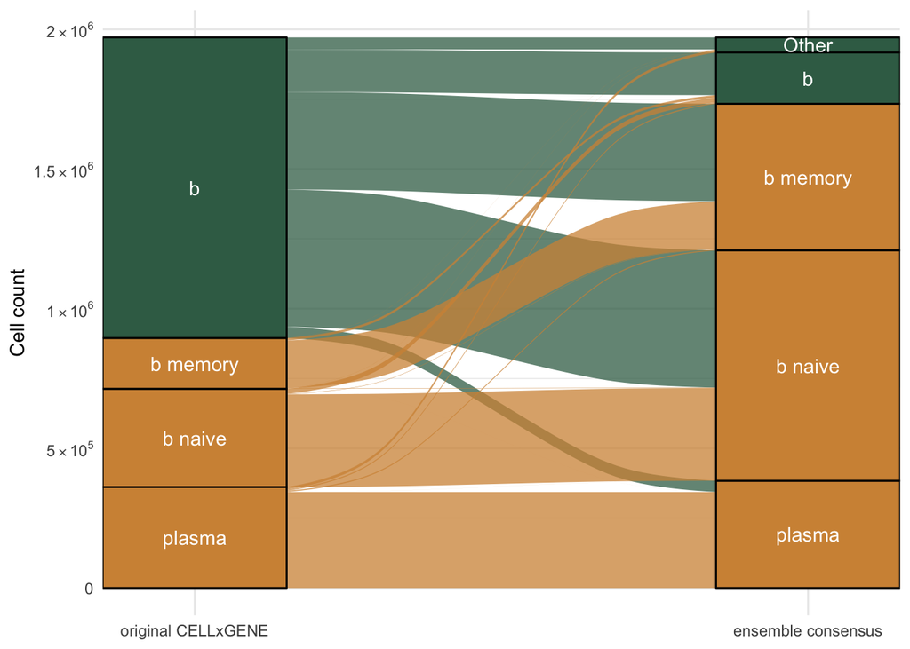

```r
b_mem_alluvial_data = cellNexus_metadata |>
  left_join(cellxgene_map,copy = TRUE)|>
  filter(unified_celltype %in% c("b memory","b naive","plasma","b")) |>
  mutate(
    unified_celltype = case_when(
      unified_celltype %in% c("b memory","b naive","plasma","b") ~ unified_celltype,
      .default="Other"
    ),
    cell_type_unified_ensemble = case_when(
      cell_type_unified_ensemble %in% c("b memory","b naive","plasma","b") ~ cell_type_unified_ensemble,
      .default="Other"
    )
  ) |>
  count(unified_celltype,cell_type_unified_ensemble) |>
  mutate(
    original_level = case_when(
      unified_celltype %in% c("b memory","b naive","plasma") ~ "L2",
      .default= "L1"
    ),
    consensus_level = case_when(
      cell_type_unified_ensemble %in% c("b memory","b naive","plasma") ~ "L2",
      .default= "L1"
    )
  ) |>
  collect()

b_mem_alluvial_data$cell_type_unified_ensemble =
  factor(b_mem_alluvial_data$cell_type_unified_ensemble,
         levels=c("Other","b","b memory","b naive","plasma"))

b_mem_alluvial_data$unified_celltype =
  factor(b_mem_alluvial_data$unified_celltype,
         levels=c("Other","b","b memory","b naive","plasma"))

library(ggalluvial)

# Immune graph level color scheme
immune_level_color = c(
  L0 = "#001959",
  L1 = "#3B6C55",
  L2 = "#D29243",
  L3 = "#F9CCF9"
)

celltype_level = c("b memory"="L2","b naive"="L2","plasma"="L2","b"="L1","Other"="L1")
celltype_color = immune_level_color[celltype_level]
names(celltype_color) = names(celltype_level)

b_mem_alluvial =
  ggplot(b_mem_alluvial_data,
         aes(y = n, axis1 = unified_celltype, axis2 = cell_type_unified_ensemble)) +
    geom_alluvium(aes(fill = original_level), width = 0.3,alpha=0.75) +
    geom_stratum(mapping = aes(fill=after_stat(stratum)),width = 0.3) +
    geom_text(stat = "stratum", mapping = aes(label = after_stat(stratum)),color="white") +
    scale_x_discrete(limits = c("unified_celltype", "cell_type_unified_ensemble"), expand = c(.05, .05),
                     labels=c("unified_celltype"="original CELLxGENE",
                              "cell_type_unified_ensemble" = "ensemble consensus")) +
    scale_fill_manual(values = c(immune_level_color,celltype_color),name="Level")+
    scale_y_continuous(breaks=c(0,5e5,1e6,1.5e6,2e6),
                       labels=sapply(
                         c("0","5%*%10^5","1%*%10^6","1.5%*%10^6","2%*%10^6"),
                         function(x){parse(text=x)}))+
    ylab("Cell count")+
    theme_minimal()+
    theme(legend.position = "none")

print(b_mem_alluvial)
```

It appears that B memory is a good candidate to as it has the highest degree of improvement.

I then counted the number of cells that are labelled as B memory cells within each tissue group and disease condition, and the number of samples that contains these cells within the same tissue group and disease condition, for both the original CELLxGENE annotation and the ensemble consensus annotation.

```r
# a count on samples and cells by tissue and disease condition
original_disease_tissue_sample_count = cellNexus_metadata|>
  left_join(cellxgene_map,copy = TRUE)|>
  filter(unified_celltype %in% c("b memory","b"),
         grepl("memory",x = cell_type)) |>
  count(tissue_groups,sample_id,disease)|>
  collect()

original_disease_tissue_count = left_join(
  x = original_disease_tissue_sample_count|>
    count(tissue_groups,disease,wt=n)|>
    rename(n_cell=n),
  y = original_disease_tissue_sample_count|>
    count(tissue_groups,disease)|>
    rename(n_sample=n)
)

original_disease_tissue_count_by_disease = split(
  original_disease_tissue_count,original_disease_tissue_count$disease)

original_disease_tissue_count_by_tissue = split(
  original_disease_tissue_count,original_disease_tissue_count$tissue_groups)

consensus_disease_tissue_sample_count = cellNexus_metadata|>
  left_join(cellxgene_map,copy = TRUE)|>
  filter(cell_type_unified_ensemble %in% c("b memory")) |>
  count(tissue_groups,sample_id,disease)|>
  collect()

consensus_disease_tissue_count = left_join(
  x = consensus_disease_tissue_sample_count|>
    count(tissue_groups,disease,wt=n)|>
    rename(n_cell=n),
  y = consensus_disease_tissue_sample_count|>
    count(tissue_groups,disease)|>
    rename(n_sample=n)
)

consensus_disease_tissue_count_by_disease = split(
  consensus_disease_tissue_count,consensus_disease_tissue_count$disease)

consensus_disease_tissue_count_by_tissue = split(
  consensus_disease_tissue_count,consensus_disease_tissue_count$tissue_groups)
```

For healthy samples, I generated a table for tissues that has at least one sample containing B memory cells in both original and ensemble consensus annotation.

```r
# find candidates for DE between tissue in healthy samples
healthy_by_tissue_comparison = left_join(
  original_disease_tissue_count_by_disease$normal |>
    select(-disease)|> rename(n_cell_original=n_cell,n_sample_original = n_sample),
  consensus_disease_tissue_count_by_disease$normal|>
    select(-disease)|> rename(n_cell_consensus=n_cell,n_sample_consensus = n_sample),
)
```

```
# A tibble: 23 × 3
   tissue_groups                            n_sample_original n_sample_consensus
   <chr>                                                <int>              <int>
 1 adipose tissue                                           2                 29
 2 blood                                                 2249               2599
 3 bone marrow                                             46                 66
 4 breast                                                 245                198
 5 digestive tract junctions and connectio…                 5                  7
 6 endocrine system                                         2                  8
 7 epithelium and mucosal tissues                           8                 25
 8 gastrointestinal accessory organs                        7                 97
 9 integumentary system (skin)                              2                 17
10 large intestine                                         41                 72
11 lymphatic system                                        61                 77
12 miscellaneous glands                                     3                  5
13 muscular system (skeletal muscles)                       1                  1
14 nasal, oral, and pharyngeal regions                     17                 27
15 oesophagus                                               4                  8
16 peritoneal and abdominal cavity structu…                 2                  2
17 renal system                                             1                 77
18 respiratory system                                     104                287
19 small intestine                                         16                 50
20 spleen                                                  33                 64
21 stomach                                                 19                 20
22 thymus                                                  37                 47
23 trachea                                                 19                 23
```

I also generated a table for disease conditions to find potential comparison between healthy samples and disease samples.

```r
# find candidates for DE between healthy and disease in each tissue
healthy_and_disease_comparison = do.call(rbind,lapply(
  intersect(names(original_disease_tissue_count_by_tissue),
            names(consensus_disease_tissue_count_by_tissue)),
  function(nn){
    df = left_join(
      original_disease_tissue_count_by_tissue[[nn]] |>
        rename(n_cell_original=n_cell,n_sample_original = n_sample),
      consensus_disease_tissue_count_by_tissue[[nn]]|>
        rename(n_cell_consensus=n_cell,n_sample_consensus = n_sample),
    )
    if(dim(df)[1]<2) return(NULL)
    return(df)
  }))
```

```
# A tibble: 28 × 4
   tissue_groups                    disease n_sample_original n_sample_consensus
   <chr>                            <chr>               <int>              <int>
 1 blood                            COVID-…               189                688
 2 blood                            common…                12                 12
 3 blood                            influe…                 5                 15
 4 blood                            normal               2249               2599
 5 blood                            post-C…                18                 18
 6 blood                            respir…                 5                 20
 7 bone marrow                      B-cell…                17                  8
 8 bone marrow                      acute …                 9                  9
 9 bone marrow                      acute …                 6                  4
10 bone marrow                      normal                 46                 66
11 breast                           breast…                20                 20
12 breast                           normal                245                198
```

[output cut: 16 more lines]

## Pseudo-bulk analysis using original and ensemble consensus annotation

I then conducted pseudo-bulk DE analysis using the R package `tidybulk`.

To factor out potential batch effects by covariates like datasets and sequencing technology, I updated the cellNexus metadata based on a deposited function: (https://gist.github.com/stemangiola/8fe6c45b79dd95a200c0fd2314ec57d0).

```r
assay_data_grouped = tribble(
  ~assay, ~assay_groups,
  "10x 3' v2", "10x Genomics 3",
  "10x 3' v3", "10x Genomics 3",
  "10x 5' v2", "10x Genomics 5",
  "10x 5' v1", "10x Genomics 5",
  "MARS-seq", "Plate based Technologies",
  "10x 3' transcription profiling", "10x Genomics 3",
  "10x 5' transcription profiling", "10x Genomics 5",
  "Smart-seq2", "Smart seq",
  "microwell-seq", "Microwell Technologies",
  "TruDrop", "TruDrop",
  "Drop-seq", "Drop based Technologies",
  "Seq-Well S3", "Microwell Technologies",
  "GEXSCOPE technology", "Other Technologies",
  "Seq-Well", "Microwell Technologies",
  "sci-RNA-seq", "Other Technologies",
  "10x 3' v1", "10x Genomics 3",
  "BD Rhapsody Whole Transcriptome Analysis", "Other Technologies",
  "BD Rhapsody Targeted mRNA", "Other Technologies",
  "CEL-seq2", "Plate based Technologies",
  "SPLiT-seq", "Other Technologies",
  "STRT-seq", "Plate based Technologies",
  "inDrop", "Drop based Technologies",
  "Smart-seq v4", "Smart seq",
  "ScaleBio single cell RNA sequencing", "Other Technologies"
)

cellNexus_metadata = cellNexus_metadata |>
  left_join(assay_data_grouped, copy=TRUE)
```

### Case 1: healthy fat vs healthy blood

Because I need pseduo-bulk data aggregated under the original CELLxGENE annotation, I pulled the relevant single-cell data and aggregated them manually for both annotations.

```r
library(tidybulk)
library(edgeR)
library(limma)
library(variancePartition)
library(patchwork)

# collect metadata
original_healthy_fat = cellNexus_metadata |>
  left_join(cellxgene_map,copy = TRUE)|>
  filter(unified_celltype %in% c("b memory","b"),
         grepl("memory",x = cell_type),
         disease=="normal",
         feature_count > 5000,
         tissue_groups%in%c("adipose tissue")) |>
  collect()

original_fat_datasets = unique(original_healthy_fat$dataset_id)

original_healthy_blood = cellNexus_metadata |>
  left_join(cellxgene_map,copy = TRUE)|>
  filter(unified_celltype %in% c("b memory","b"),
         grepl("memory",x = cell_type),
         disease=="normal",
         feature_count > 5000,
         dataset_id %in% !!original_fat_datasets,
         tissue_groups %in% c("blood")) |>
  collect()

consensus_healthy_fat = cellNexus_metadata |>
  left_join(cellxgene_map,copy = TRUE)|>
  filter(cell_type_unified_ensemble %in% c("b memory"),
         disease=="normal",
         feature_count > 5000,
         #dataset_id %in% !!original_fat_datasets,
         assay_groups %in% c("10x Genomics 5","10x Genomics 3"),
         tissue_groups%in%c("adipose tissue")) |>
  collect()

consensus_fat_datasets = unique(consensus_healthy_fat$dataset_id)

consensus_healthy_blood = cellNexus_metadata |>
  left_join(cellxgene_map,copy = TRUE)|>
  filter(cell_type_unified_ensemble %in% c("b memory"),
         disease=="normal",
         feature_count > 5000,
         dataset_id %in% !!consensus_fat_datasets,
         tissue_groups %in% c("blood")) |>
  collect()

original_healthy_fat_vs_blood_SCE = rbind(original_healthy_fat,original_healthy_blood)|>
  get_single_cell_experiment()

consensus_healthy_fat_vs_blood_SCE = rbind(consensus_healthy_fat,consensus_healthy_blood)|>
  get_single_cell_experiment()
```

I filtered the aggregated pseudo-bulk data to keep only the features that are abundant across 70% of the sample in at least one tissue, and then normalized the gene expression counts with method ‘TMMwsp’.

```r
# aggregate from single cell data
as_SE = function(x){
  rn = rownames(x)
  x = as(x,"RangedSummarizedExperiment")
  rownames(x) = rn
  #colnames(x) = paste0(x@colData$sample_id,"___",x@colData$tissue_groups)
  return(x)
}

original_healthy_fat_vs_blood_SE = original_healthy_fat_vs_blood_SCE |>
  scuttle::aggregateAcrossCells(
    ids = paste0(original_healthy_fat_vs_blood_SCE@colData$tissue_groups,
                 "_",original_healthy_fat_vs_blood_SCE@colData$donor_id),
    statistics = "sum"
  ) |> as_SE() |>
  keep_abundant_per_category(formula_design = ~ tissue_groups,
                minimum_count_per_million = 10,
                minimum_proportion = 0.7) |>
  scale_abundance(method = "TMMwsp") #|>
  #resolve_complete_confounders_of_non_interest(sex,dataset_id,assay_groups)

print(dim(original_healthy_fat_vs_blood_SE))
```

```
[1] 6096   14
```

```r
consensus_healthy_fat_vs_blood_SE = consensus_healthy_fat_vs_blood_SCE |>
  scuttle::aggregateAcrossCells(
    ids = paste0(consensus_healthy_fat_vs_blood_SCE@colData$tissue_groups,
                 "_",consensus_healthy_fat_vs_blood_SCE@colData$donor_id),
    statistics = "sum"
  ) |> as_SE() |>
  keep_abundant_per_category(formula_design = ~ tissue_groups,
                minimum_count_per_million = 10,
                minimum_proportion = 0.7) |>
  scale_abundance(method = "TMMwsp") #|>
  #resolve_complete_confounders_of_non_interest(sex,dataset_id,assay_groups)

print(dim(consensus_healthy_fat_vs_blood_SE))
```

```
[1] 5849   28
```

Then, I conducted differential expression analysis through ‘dream()’ with a focus on coefficients of tissue groups in pseudobulk data aggregated based on original CELLxGENE annotation:

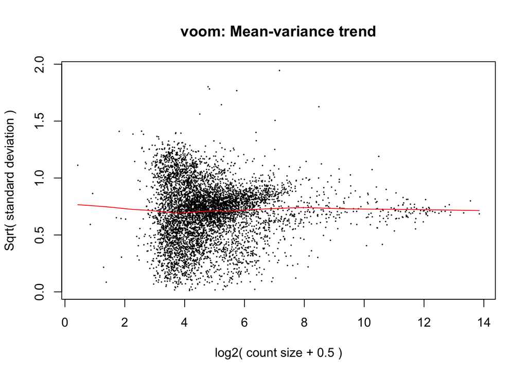

```r
# simplify dataset id and tissue group for contrast names
simplify_complex_entry_in_colData = function(se,levels){
  se@colData$tissue_groups_simplified =
    paste0("tissue_",as.numeric(factor(se@colData$tissue_groups,levels = levels)))
  if(is.null(se@colData$dataset_id___altered)){
    se@colData$dataset_id_simplified =
      paste0("dataset_",as.numeric(factor(se@colData$dataset_id)))
  }else{
    se@colData$dataset_id_simplified =
      paste0("dataset_",as.numeric(factor(se@colData$dataset_id___altered)))
  }
  if(is.null(se@colData$assay_groups___altered)){
    se@colData$assay_groups_simplified =
      paste0("assay_",as.numeric(factor(se@colData$assay_groups)))
  }else{
    se@colData$assay_groups_simplified =
      paste0("assay_",as.numeric(factor(se@colData$assay_groups___altered)))
  }
  return(se)
}

# DE using dream()
original_healthy_fat_vs_blood_SE =
  original_healthy_fat_vs_blood_SE |>
  simplify_complex_entry_in_colData(levels=c("blood","adipose tissue"))

original_healthy_fat_vs_blood_formula = ~ tissue_groups_simplified + sex + (1|donor_id)
original_healthy_fat_vs_blood_dge =
  original_healthy_fat_vs_blood_SE@assays@data$counts |>
  DGEList()|>
  calcNormFactors(method="TMMwsp")

original_healthy_fat_vs_blood_voom =
  original_healthy_fat_vs_blood_dge |>
  voomWithDreamWeights(original_healthy_fat_vs_blood_formula,
                       original_healthy_fat_vs_blood_SE@colData,
                       plot = TRUE)
```

```r
original_healthy_fat_vs_blood_fit =
  original_healthy_fat_vs_blood_voom |>
  dream(original_healthy_fat_vs_blood_formula,
        original_healthy_fat_vs_blood_SE@colData) |>
  eBayes()

head(original_healthy_fat_vs_blood_fit$design,3)
```

```
                       (Intercept) tissue_groups_simplifiedtissue_2 sexmale
adipose tissue_PD45814           1                                1       1
adipose tissue_PD47171           1                                1       0
blood_PD43824                    1                                0       1
```

and the ensemble consensus annotation:

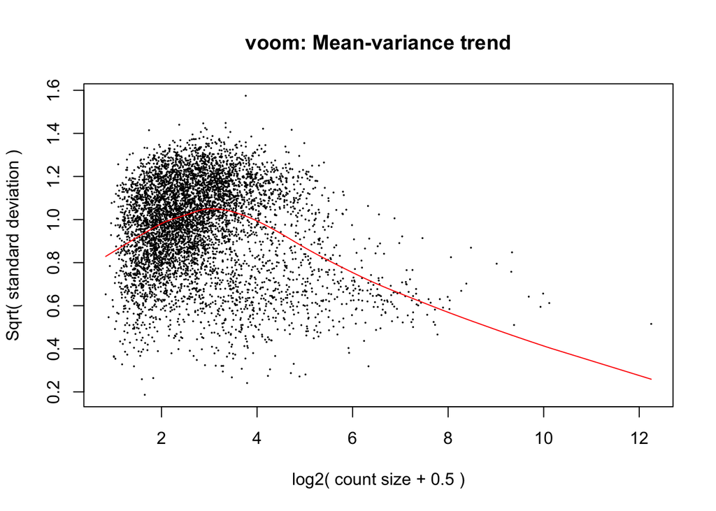

```r
consensus_healthy_fat_vs_blood_SE =
  consensus_healthy_fat_vs_blood_SE |>
  simplify_complex_entry_in_colData(levels=c("blood","adipose tissue"))

consensus_healthy_fat_vs_blood_formula =
  ~ tissue_groups_simplified + sex + (1|donor_id) + (1|dataset_id_simplified)

consensus_healthy_fat_vs_blood_dge =
  consensus_healthy_fat_vs_blood_SE@assays@data$counts |>
  DGEList()|>
  calcNormFactors(method="TMMwsp")

consensus_healthy_fat_vs_blood_voom =
  consensus_healthy_fat_vs_blood_dge |>
  voomWithDreamWeights(consensus_healthy_fat_vs_blood_formula,
                       consensus_healthy_fat_vs_blood_SE@colData,
                       plot = TRUE)
```

```r
consensus_healthy_fat_vs_blood_fit =
  consensus_healthy_fat_vs_blood_voom |>
  dream(consensus_healthy_fat_vs_blood_formula,
        consensus_healthy_fat_vs_blood_SE@colData) |>
  eBayes()

head(consensus_healthy_fat_vs_blood_fit$design,3)
```

```
                     (Intercept) tissue_groups_simplifiedtissue_2 sexmale
adipose tissue_Hs001           1                                1       0
adipose tissue_Hs002           1                                1       0
adipose tissue_Hs004           1                                1       0
```

I plotted the distribution of counts per sample and p-values,

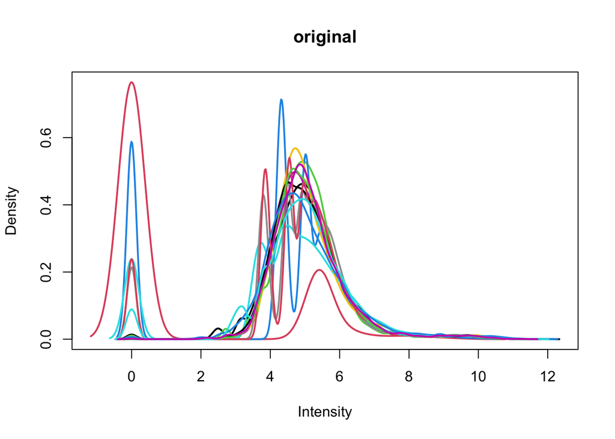

```r
# Histogram of p-values
limma::plotDensities(log1p(original_healthy_fat_vs_blood_SE@assays@data$counts_scaled),
                     legend=FALSE,main="original")
```

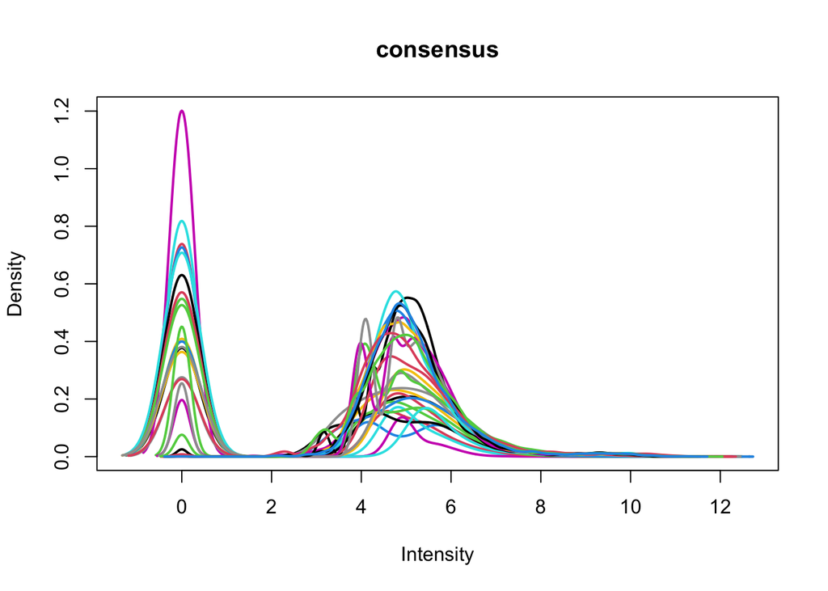

```r
limma::plotDensities(log1p(consensus_healthy_fat_vs_blood_SE@assays@data$counts_scaled),
                     legend=FALSE,main="consensus")
```

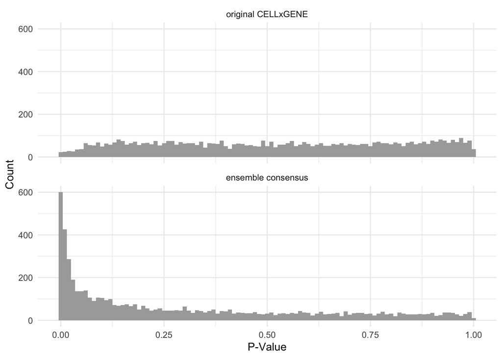

```r
ori_fat_blood_pval_hist =
  original_healthy_fat_vs_blood_fit |>
  topTable(number = Inf,coef = "tissue_groups_simplifiedtissue_2") |>
  mutate(
    annotation_method = factor("original CELLxGENE",
                               levels=c("original CELLxGENE","ensemble consensus")))

con_fat_blood_pval_hist =
  consensus_healthy_fat_vs_blood_fit |>
  topTable(number = Inf,coef = "tissue_groups_simplifiedtissue_2") |>
  mutate(
    annotation_method = factor("ensemble consensus",
                               levels=c("original CELLxGENE","ensemble consensus")))

b_mem_pval_hist =
  rbind(ori_fat_blood_pval_hist,con_fat_blood_pval_hist)|>
  ggplot() +
  geom_histogram(mapping = aes(x = P.Value),binwidth = 0.01,fill="darkgrey") +
  facet_wrap(~annotation_method,ncol=1,nrow=2) +
  labs(x="P-Value",y="Count")+
  theme_minimal() +
  theme(legend.position = "none")

print(b_mem_pval_hist)
```

and the LFC-mean plot for QC.

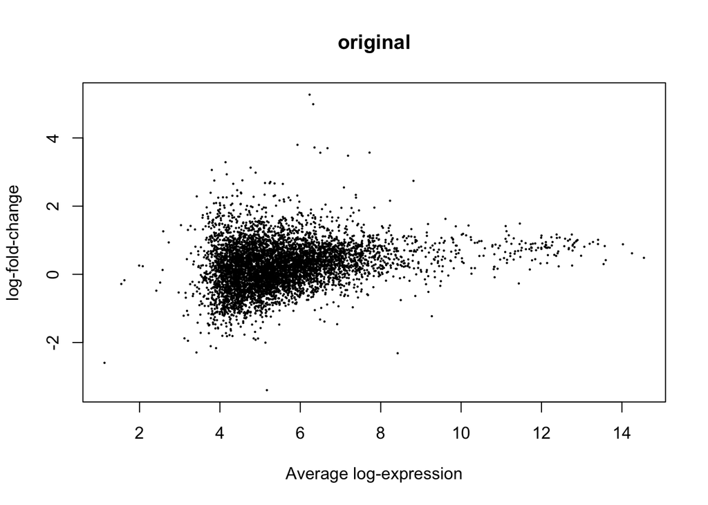

```r
# LFC-mean
original_healthy_fat_vs_blood_fit |>
  plotMA(main="original")
```

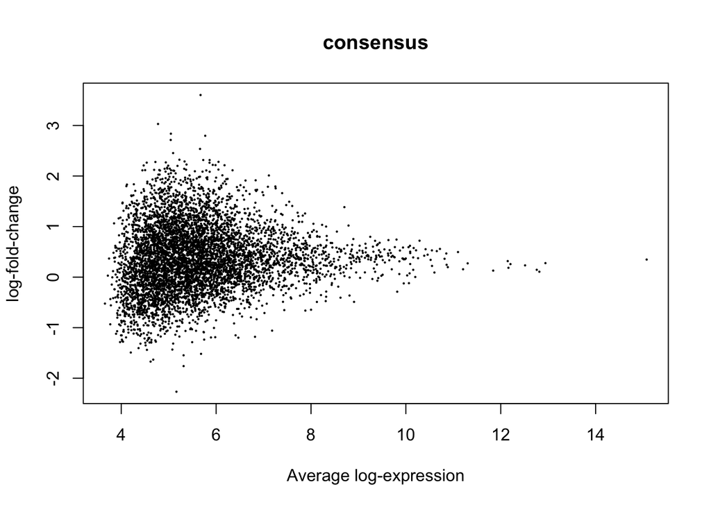

```r
consensus_healthy_fat_vs_blood_fit |>
  plotMA(main="consensus")
```

Then I selected the top ten up- and down-regulated genes in adipose tissues using both the original and the consensus label:

```r
library(org.Hs.eg.db)
ori_fat_blood_outcome = ori_fat_blood_pval_hist |>
  rownames_to_column(var=".feature") |>
  arrange(adj.P.Val) |> mutate(
  genename = mapIds(
    org.Hs.eg.db,
    keys = .feature,
    column = "GENENAME",
    keytype = "ENSEMBL",
    multiVals = "first"),
  symbol = mapIds(
    org.Hs.eg.db,
    keys = .feature,
    column = "SYMBOL",
    keytype = "ENSEMBL",
    multiVals = "first")
)

print("original label:")
```

```
[1] "original label:"
```

```r
ori_fat_blood_outcome |>   filter(logFC>0) |>
  head(10)  |> dplyr::select(genename,symbol,logFC,P.Value,adj.P.Val) |> as.tibble() |> print()
```

```
# A tibble: 10 × 5
   genename                                       symbol logFC P.Value adj.P.Val
   <chr>                                          <chr>  <dbl>   <dbl>     <dbl>
 1 Fos proto-oncogene, AP-1 transcription factor… FOS     7.76 4.18e-5     0.255
 2 casein kinase 1 gamma 1                        CSNK1…  4.40 4.93e-4     1.000
 3 TNF superfamily member 9                       TNFSF9  4.05 1.16e-3     1.000
 4 H4 clustered histone 2                         H4C2    4.48 1.20e-3     1.000
 5 heat shock protein family A (Hsp70) member 1B  HSPA1B  3.96 1.43e-3     1.000
 6 solute carrier family 18 member B1             SLC18…  3.80 1.47e-3     1.000
 7 C1RL antisense RNA 1                           C1RL-…  3.69 1.57e-3     1.000
 8 C-C motif chemokine ligand 4                   CCL4    4.88 2.28e-3     1.000
 9 HECT domain E3 ubiquitin protein ligase 4      HECTD4  3.09 2.39e-3     1.000
10 solute carrier family 35 member A5             SLC35…  3.30 2.47e-3     1.000
```

```r
ori_fat_blood_outcome |>   filter(logFC<0) |>
  head(10)  |> dplyr::select(genename,symbol,logFC,P.Value,adj.P.Val) |> as.tibble() |> print()
```

```
# A tibble: 10 × 5
   genename                                       symbol logFC P.Value adj.P.Val
   <chr>                                          <chr>  <dbl>   <dbl>     <dbl>
 1 immunoglobulin kappa variable 3-11             IGKV3… -5.14 7.10e-4     1.000
 2 immunoglobulin heavy variable 3-23             IGHV3… -3.89 1.55e-3     1.000
 3 immunoglobulin kappa variable 1-39             IGKV1… -3.78 2.46e-3     1.000
 4 immunoglobulin lambda variable 2-8             IGLV2… -4.04 3.50e-3     1.000
 5 KLF transcription factor 2                     KLF2   -3.05 4.38e-3     1.000
 6 HCK proto-oncogene, Src family tyrosine kinase HCK    -3.66 4.40e-3     1.000
 7 sphingosine-1-phosphate receptor 4             S1PR4  -2.79 5.15e-3     1.000
 8 immunoglobulin lambda variable 1-44            IGLV1… -2.86 7.79e-3     1.000
 9 bridging integrator 2                          BIN2   -2.86 8.49e-3     1.000
10 major histocompatibility complex, class II, D… HLA-D… -2.35 8.85e-3     1.000
```

```r
con_fat_blood_outcome = con_fat_blood_pval_hist |>
  rownames_to_column(var=".feature") |>
  arrange(adj.P.Val) |> mutate(
  genename = mapIds(
    org.Hs.eg.db,
    keys = .feature,
    column = "GENENAME",
    keytype = "ENSEMBL",
    multiVals = "first"),
  symbol = mapIds(
    org.Hs.eg.db,
    keys = .feature,
    column = "SYMBOL",
    keytype = "ENSEMBL",
    multiVals = "first")
)

print("consensus label:")
```

```
[1] "consensus label:"
```

```r
con_fat_blood_outcome |>  filter(logFC>0) |>
  head(10)  |> dplyr::select(genename,symbol,logFC,P.Value,adj.P.Val) |> as.tibble() |> print()
```

```
# A tibble: 10 × 5
   genename                                       symbol logFC P.Value adj.P.Val
   <chr>                                          <chr>  <dbl>   <dbl>     <dbl>
 1 C-X-C motif chemokine receptor 4               CXCR4   3.34 5.28e-9 0.0000308
 2 KLF transcription factor 6                     KLF6    1.99 2.63e-7 0.000296
 3 CD69 molecule                                  CD69    4.40 7.03e-7 0.000410
 4 CD55 molecule (Cromer blood group)             CD55    2.13 1.64e-6 0.000637
 5 G protein-coupled receptor 183                 GPR183  1.98 5.41e-6 0.00132
 6 Jun proto-oncogene, AP-1 transcription factor… JUN     3.54 7.15e-6 0.00149
 7 zinc finger protein 331                        ZNF331  3.77 8.22e-6 0.00160
 8 spermidine/spermine N1-acetyltransferase 1     SAT1    2.18 2.79e-5 0.00245
 9 JunB proto-oncogene, AP-1 transcription facto… JUNB    3.06 4.81e-5 0.00369
10 long intergenic non-protein coding RNA, p53 i… LINC-…  1.48 6.69e-5 0.00451
```

```r
con_fat_blood_outcome |>  filter(logFC<0) |>
  head(10)  |> dplyr::select(genename,symbol,logFC,P.Value,adj.P.Val) |> as.tibble() |> print()
```

```
# A tibble: 10 × 5
   genename                                       symbol logFC P.Value adj.P.Val
   <chr>                                          <chr>  <dbl>   <dbl>     <dbl>
 1 cyclin dependent kinase inhibitor 2D           CDKN2D -3.01 1.32e-8 0.0000385
 2 FGR proto-oncogene, Src family tyrosine kinase FGR    -3.47 2.95e-7 0.000296
 3 proteasome 26S subunit, ATPase 6               PSMC6  -2.94 3.02e-7 0.000296
 4 sphingosine-1-phosphate receptor 4             S1PR4  -2.90 3.04e-7 0.000296
 5 general transcription factor IIH subunit 5     GTF2H5 -2.66 4.39e-7 0.000320
 6 aldehyde dehydrogenase 16 family member A1     ALDH1… -2.70 4.45e-7 0.000320
 7 mitochondrial ribosomal protein S12            MRPS12 -2.59 4.92e-7 0.000320
 8 annexin A2                                     ANXA2  -3.28 1.22e-6 0.000637
 9 PYD and CARD domain containing                 PYCARD -3.01 1.31e-6 0.000637
10 ceramide-1-phosphate transfer protein          CPTP   -2.13 1.53e-6 0.000637
```

I checked the volcano plot:

```r
# Top residency gene candidates

original_healthy_fat_vs_blood_SE@colData |> as_tibble() |>
  count(tissue_groups,tissue_groups_simplified)
```

| tissue_groups | tissue_groups_simplified | n |
| --- | --- | --- |
| adipose tissue | tissue_2 | 2 |
| blood | tissue_1 | 12 |

```r
consensus_healthy_fat_vs_blood_SE@colData |> as_tibble() |>
  count(tissue_groups,tissue_groups_simplified)
```

| tissue_groups | tissue_groups_simplified | n |
| --- | --- | --- |
| adipose tissue | tissue_2 | 16 |
| blood | tissue_1 | 12 |

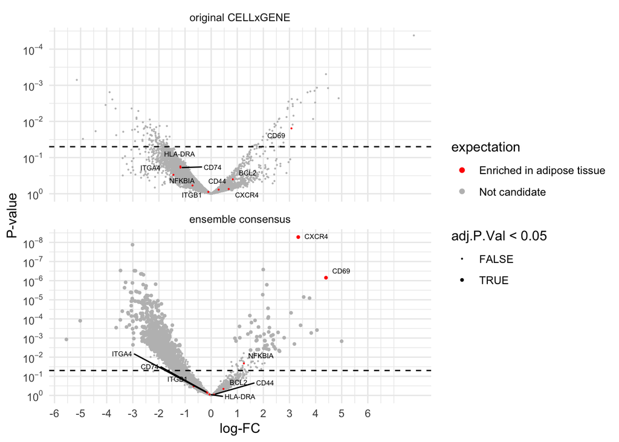

```r
fat_enrich_blood_genes = c(
"CXCR4","ITGA4","ITGB1","CD44","BCL2",
"HLA-DRA","CD69","CD74","NFKBIA","TNFAIP3"
)

# Create volcano plots
b_mem_volcano_data =
  rbind(
    ori_fat_blood_outcome |>
    # Add candidate annotation
    mutate(expectation  = case_when(
        symbol %in% fat_enrich_blood_genes ~ "Enriched in adipose tissue",
        .default = "Not candidate"
        ),
        label = case_when(
          symbol %in% fat_enrich_blood_genes ~ symbol,
          .default = NA
        ),
        annotation_method = factor("original CELLxGENE",
                                   levels=c("original CELLxGENE","ensemble consensus"))
    ) |> arrange(desc(expectation)),
    con_fat_blood_outcome |>
    # Add candidate annotation
    mutate(expectation  = case_when(
        symbol %in% fat_enrich_blood_genes ~ "Enriched in adipose tissue",
        .default = "Not candidate"
        ),
        label = case_when(
          symbol %in% fat_enrich_blood_genes ~ symbol,
          .default = NA
        ),
        annotation_method = factor("ensemble consensus",
                                   levels=c("original CELLxGENE","ensemble consensus"))
    ) |> arrange(desc(expectation))
  )

# Plot
b_mem_volcano = b_mem_volcano_data |>
  ggplot(aes(x = logFC, y = P.Value)) +
  geom_point(aes(color = expectation, size = adj.P.Val < 0.05)) +
  geom_hline(yintercept = 0.05,color="black",linetype="dashed")+
  ggrepel::geom_text_repel(aes(label = label), size = 2, max.overlaps = 20) +
  scale_x_continuous(breaks=seq(-6,6,1))+
  scale_y_continuous(trans = "log10_reverse",
                     breaks = 10^seq(-9,0,1),
                     labels=sapply(seq(-9,0,1),function(x){
                       parse(text=sprintf("10^%d",x))
                       })) +
  scale_color_manual(values = c("Enriched in adipose tissue" = "red","Not candidate" ="grey")) +
  scale_size_manual(values = c("TRUE" = 0.75, "FALSE" = 0.1)) +
  facet_wrap(facets=vars(annotation_method),ncol=1,nrow=2,scales="free_y")+
  theme_minimal() +
  labs(x="log-FC",y="P-value")

print(b_mem_volcano)
```

The aggregated result figure for manuscript:

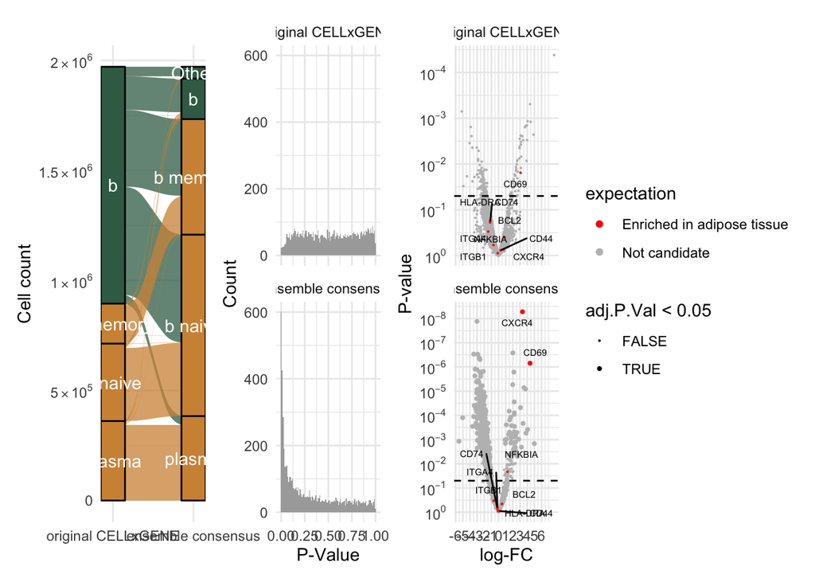

```r
b_mem_alluvial + b_mem_pval_hist + b_mem_volcano + plot_layout(ncol = 3,nrow = 1)
```